# Prediction classification of exercise data

Haridas P T

March 9, 2021

The files are kept in the ProjectWorking Directory

Import the input and output files

```r
set.seed(33333)
if (file.exists("./pml-training.csv")) {
  rawtraining <- read.csv("./pml-training.csv",na.strings = c("NA",""))
} else {
  print("ERROR: The file pml-training.csv is not in the current working directory")
}
if (file.exists("./pml-testing.csv")) {
  rawprediction <- read.csv("./pml-testing.csv",na.strings = c("NA",""))
} else {
  print("ERROR: The file pml-testing.csv is not in the current working directory");
}
dim(rawtraining);dim(rawprediction);
```

```
## [1] 19622   160
```

```
## [1]  20 160
```

Keep only those rows where sum of “NA”s is column are zero

```r
trainingMaster <- rawtraining[, colSums(is.na(rawtraining)) == 0]
prediction <- rawprediction[, colSums(is.na(rawprediction)) == 0]
```

find differences in column names if any

```r
if(identical(names(trainingMaster),names(prediction))){
  print("The non na cell names are same");
} else {
  print("These are the columns which are different among non na columns");
  print(paste0( names(trainingMaster)[!(names(trainingMaster) %in% names(prediction))]," is absent in prediction"));
  print(paste0( names(prediction)[!(names(trainingMaster) %in% names(prediction))]," is absent in trainingMaster"));
}
```

```
## [1] "These are the columns which are different among non na columns"
## [1] "classe is absent in prediction"
## [1] "problem_id is absent in trainingMaster"
```

Now, remove the non sensor columns which obviously is not going to impact the results

```r
trainingMaster_non_sensor_clmn_names=c("X","user_name","raw_timestamp_part_1","raw_timestamp_part_2","cvtd_timestamp","new_window","num_window")
prediction_non_sensor_clmn_names=c("X","user_name","raw_timestamp_part_1","raw_timestamp_part_2","cvtd_timestamp","new_window","num_window","problem_id")
trainingMaster<-trainingMaster[,!(names(trainingMaster) %in% trainingMaster_non_sensor_clmn_names)]
prediction<-prediction[,!(names(prediction) %in% prediction_non_sensor_clmn_names)]
print(paste0("After removing the non sensor columns"))
```

```
## [1] "After removing the non sensor columns"
```

```r
print(dim(trainingMaster))
```

```
## [1] 19622    53
```

```r
print(dim(prediction));
```

```
## [1] 20 52
```

check the type of variables

```r
sapply(trainingMaster,class);
```

```
##            roll_belt           pitch_belt             yaw_belt
##            "numeric"            "numeric"            "numeric"
##     total_accel_belt         gyros_belt_x         gyros_belt_y
##            "integer"            "numeric"            "numeric"
##         gyros_belt_z         accel_belt_x         accel_belt_y
##            "numeric"            "integer"            "integer"
##         accel_belt_z        magnet_belt_x        magnet_belt_y
##            "integer"            "integer"            "integer"
##        magnet_belt_z             roll_arm            pitch_arm
##            "integer"            "numeric"            "numeric"
##              yaw_arm      total_accel_arm          gyros_arm_x
##            "numeric"            "integer"            "numeric"
##          gyros_arm_y          gyros_arm_z          accel_arm_x
##            "numeric"            "numeric"            "integer"
##          accel_arm_y          accel_arm_z         magnet_arm_x
##            "integer"            "integer"            "integer"
##         magnet_arm_y         magnet_arm_z        roll_dumbbell
##            "integer"            "integer"            "numeric"
##       pitch_dumbbell         yaw_dumbbell total_accel_dumbbell
##            "numeric"            "numeric"            "integer"
##     gyros_dumbbell_x     gyros_dumbbell_y     gyros_dumbbell_z
##            "numeric"            "numeric"            "numeric"
##     accel_dumbbell_x     accel_dumbbell_y     accel_dumbbell_z
##            "integer"            "integer"            "integer"
##    magnet_dumbbell_x    magnet_dumbbell_y    magnet_dumbbell_z
##            "integer"            "integer"            "numeric"
##         roll_forearm        pitch_forearm          yaw_forearm
##            "numeric"            "numeric"            "numeric"
##  total_accel_forearm      gyros_forearm_x      gyros_forearm_y
##            "integer"            "numeric"            "numeric"
##      gyros_forearm_z      accel_forearm_x      accel_forearm_y
##            "numeric"            "integer"            "integer"
##      accel_forearm_z     magnet_forearm_x     magnet_forearm_y
##            "integer"            "integer"            "numeric"
##     magnet_forearm_z               classe
##            "numeric"          "character"
```

change the variable classe as a factor variable

```r
trainingMaster$classe<-as.factor(trainingMaster$classe)
```

Since columns are cleaned up same proceed to the next step of partitioning the data keep 70% of training data for training and remaining for testing

```r
library(caret)
library(randomForest);
trainingIDs<-createDataPartition(trainingMaster$classe,p=0.7,list=FALSE)
training<-trainingMaster[trainingIDs,]
testing<-trainingMaster[-trainingIDs,]
summary(training);
```

```
##    roll_belt        pitch_belt          yaw_belt      total_accel_belt
##  Min.   :-28.80   Min.   :-55.8000   Min.   :-180.0   Min.   : 0.00
##  1st Qu.:  1.11   1st Qu.:  1.6100   1st Qu.: -88.3   1st Qu.: 3.00
##  Median :114.00   Median :  5.2600   Median : -12.3   Median :17.00
##  Mean   : 64.63   Mean   :  0.1509   Mean   : -10.7   Mean   :11.33
##  3rd Qu.:123.00   3rd Qu.: 14.9000   3rd Qu.:  13.7   3rd Qu.:18.00
##  Max.   :162.00   Max.   : 60.2000   Max.   : 179.0   Max.   :29.00
##   gyros_belt_x        gyros_belt_y       gyros_belt_z      accel_belt_x
##  Min.   :-1.040000   Min.   :-0.53000   Min.   :-1.3500   Min.   :-120.000
##  1st Qu.:-0.030000   1st Qu.: 0.00000   1st Qu.:-0.2000   1st Qu.: -21.000
##  Median : 0.030000   Median : 0.02000   Median :-0.1000   Median : -15.000
##  Mean   :-0.005968   Mean   : 0.03981   Mean   :-0.1311   Mean   :  -5.399
##  3rd Qu.: 0.110000   3rd Qu.: 0.11000   3rd Qu.:-0.0200   3rd Qu.:  -5.000
##  Max.   : 2.220000   Max.   : 0.64000   Max.   : 1.6200   Max.   :  85.000
##   accel_belt_y     accel_belt_z  magnet_belt_x    magnet_belt_y
##  Min.   :-54.00   Min.   :-275   Min.   :-49.00   Min.   :354.0
##  1st Qu.:  3.00   1st Qu.:-162   1st Qu.:  9.00   1st Qu.:581.0
##  Median : 35.00   Median :-153   Median : 35.00   Median :601.0
##  Mean   : 30.24   Mean   : -73   Mean   : 56.02   Mean   :593.5
##  3rd Qu.: 61.00   3rd Qu.:  27   3rd Qu.: 60.00   3rd Qu.:610.0
##  Max.   :164.00   Max.   : 104   Max.   :485.00   Max.   :673.0
##  magnet_belt_z       roll_arm         pitch_arm          yaw_arm
##  Min.   :-623.0   Min.   :-180.00   Min.   :-87.800   Min.   :-180.0000
##  1st Qu.:-375.0   1st Qu.: -32.00   1st Qu.:-25.800   1st Qu.: -43.2000
##  Median :-320.0   Median :   0.00   Median :  0.000   Median :   0.0000
##  Mean   :-345.9   Mean   :  17.56   Mean   : -4.822   Mean   :  -0.5827
##  3rd Qu.:-306.0   3rd Qu.:  77.10   3rd Qu.: 11.000   3rd Qu.:  46.4000
##  Max.   : 289.0   Max.   : 180.00   Max.   : 88.500   Max.   : 180.0000
##  total_accel_arm  gyros_arm_x        gyros_arm_y      gyros_arm_z
##  Min.   : 1.00   Min.   :-6.37000   Min.   :-3.400   Min.   :-2.3300
##  1st Qu.:17.00   1st Qu.:-1.27000   1st Qu.:-0.800   1st Qu.:-0.0700
##  Median :27.00   Median : 0.10000   Median :-0.260   Median : 0.2300
##  Mean   :25.48   Mean   : 0.06762   Mean   :-0.267   Mean   : 0.2714
##  3rd Qu.:33.00   3rd Qu.: 1.59000   3rd Qu.: 0.140   3rd Qu.: 0.7200
##  Max.   :65.00   Max.   : 4.87000   Max.   : 2.840   Max.   : 3.0200
##   accel_arm_x       accel_arm_y       accel_arm_z       magnet_arm_x
##  Min.   :-404.00   Min.   :-318.00   Min.   :-630.00   Min.   :-584.0
##  1st Qu.:-240.00   1st Qu.: -55.00   1st Qu.:-140.00   1st Qu.:-298.0
##  Median : -46.00   Median :  14.00   Median : -47.00   Median : 293.0
##  Mean   : -59.72   Mean   :  32.31   Mean   : -71.07   Mean   : 193.5
```

[output cut: 36 more lines]

```
##  Max.   : 89.80   Max.   : 180.00   Max.   :79.00       Max.   : 3.9700
##  gyros_forearm_y    gyros_forearm_z   accel_forearm_x   accel_forearm_y
##  Min.   :-7.02000   Min.   :-7.9400   Min.   :-498.00   Min.   :-632.0
##  1st Qu.:-1.49000   1st Qu.:-0.1800   1st Qu.:-179.00   1st Qu.:  56.0
##  Median : 0.03000   Median : 0.0800   Median : -57.00   Median : 201.0
##  Mean   : 0.04986   Mean   : 0.1395   Mean   : -62.41   Mean   : 164.6
##  3rd Qu.: 1.62000   3rd Qu.: 0.4900   3rd Qu.:  75.00   3rd Qu.: 313.0
##  Max.   : 6.13000   Max.   : 4.3100   Max.   : 477.00   Max.   : 591.0
##  accel_forearm_z   magnet_forearm_x  magnet_forearm_y magnet_forearm_z classe
##  Min.   :-446.00   Min.   :-1280.0   Min.   :-892.0   Min.   :-973.0   A:3906
##  1st Qu.:-182.00   1st Qu.: -619.0   1st Qu.:   6.0   1st Qu.: 195.0   B:2658
##  Median : -39.00   Median : -386.0   Median : 593.0   Median : 509.0   C:2396
##  Mean   : -55.12   Mean   : -315.2   Mean   : 380.7   Mean   : 394.2   D:2252
##  3rd Qu.:  26.00   3rd Qu.:  -76.0   3rd Qu.: 737.0   3rd Qu.: 652.0   E:2525
##  Max.   : 291.00   Max.   :  672.0   Max.   :1480.0   Max.   :1090.0
```

##Classifier rpart Now attempt rpart classifier

```r
modFit<-train(classe ~.,method="rpart",data=training)
print(modFit$finalModel)
```

```
## n= 13737
##
## node), split, n, loss, yval, (yprob)
##       * denotes terminal node
##
##  1) root 13737 9831 A (0.28 0.19 0.17 0.16 0.18)
##    2) roll_belt< 130.5 12579 8683 A (0.31 0.21 0.19 0.18 0.11)
##      4) pitch_forearm< -33.95 1093    9 A (0.99 0.0082 0 0 0) *
##      5) pitch_forearm>=-33.95 11486 8674 A (0.24 0.23 0.21 0.2 0.12)
##       10) magnet_dumbbell_y< 439.5 9728 6971 A (0.28 0.18 0.24 0.19 0.11)
##         20) roll_forearm< 124.5 6101 3617 A (0.41 0.18 0.18 0.17 0.061) *
##         21) roll_forearm>=124.5 3627 2421 C (0.075 0.18 0.33 0.23 0.19) *
##       11) magnet_dumbbell_y>=439.5 1758  856 B (0.031 0.51 0.046 0.22 0.19) *
##    3) roll_belt>=130.5 1158   10 E (0.0086 0 0 0 0.99) *
```

```r
print(modFit$results$Accuracy)
```

```
## [1] 0.5195992 0.4133979 0.3300400
```

**accuracy** is only **51%** which is not acceptable

```r
library(rattle)
```

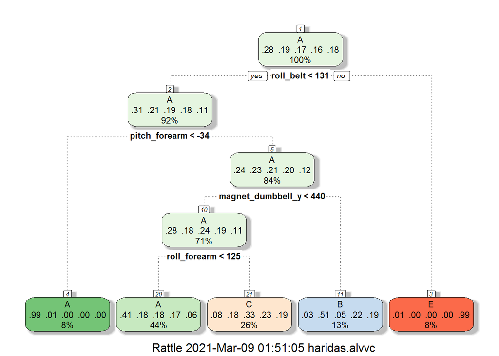

```r
fancyRpartPlot(modFit$finalModel)
```

Attempting **random forest** classifier with default crossvalidation

```r
trControl <- trainControl(method = "cv")
start_time <- Sys.time()
modFitRF_trainingD_allvars<-train(classe ~., method="rf",data=training,trControl=trControl)
end_time <- Sys.time()
print(paste0("The rf training with all training data and all variables took ", end_time-start_time))
```

```
## [1] "The rf training with all training data and all variables took 24.3068476637205"
```

```r
confusionMatrix(modFitRF_trainingD_allvars)
```

```
## Cross-Validated (10 fold) Confusion Matrix
##
## (entries are percentual average cell counts across resamples)
##
##           Reference
## Prediction    A    B    C    D    E
##          A 28.4  0.2  0.0  0.0  0.0
##          B  0.0 19.1  0.2  0.0  0.0
##          C  0.0  0.1 17.3  0.3  0.0
##          D  0.0  0.0  0.0 16.0  0.0
##          E  0.0  0.0  0.0  0.0 18.3
##
##  Accuracy (average) : 0.9919
```

```r
print(modFitRF_trainingD_allvars$finalModel)
```

```
##
## Call:
##  randomForest(x = x, y = y, mtry = param$mtry)
##                Type of random forest: classification
##                      Number of trees: 500
## No. of variables tried at each split: 2
##
##         OOB estimate of  error rate: 0.79%
## Confusion matrix:
##      A    B    C    D    E  class.error
## A 3903    2    1    0    0 0.0007680492
## B   17 2631   10    0    0 0.0101580135
## C    0   21 2372    3    0 0.0100166945
## D    0    0   46 2205    1 0.0208703375
## E    0    0    1    7 2517 0.0031683168
```

```r
modFitRF_trainingD_allvars$finalModel$importance
```

```
##                      MeanDecreaseGini
## roll_belt                   512.96061
## pitch_belt                  345.31282
## yaw_belt                    429.54047
## total_accel_belt            170.61724
## gyros_belt_x                124.99055
## gyros_belt_y                122.09123
## gyros_belt_z                215.26902
## accel_belt_x                139.73268
## accel_belt_y                136.05161
## accel_belt_z                274.60520
## magnet_belt_x               191.86326
## magnet_belt_y               269.65836
## magnet_belt_z               270.92191
## roll_arm                    236.89306
## pitch_arm                   160.78656
## yaw_arm                     186.32152
## total_accel_arm             121.18486
## gyros_arm_x                 154.37957
## gyros_arm_y                 141.84316
## gyros_arm_z                  90.21503
## accel_arm_x                 195.10497
## accel_arm_y                 162.05279
## accel_arm_z                 148.25961
## magnet_arm_x                202.54022
## magnet_arm_y                201.75569
## magnet_arm_z                173.92894
## roll_dumbbell               271.81005
## pitch_dumbbell              180.48130
## yaw_dumbbell                212.61700
## total_accel_dumbbell        201.86445
## gyros_dumbbell_x            138.78981
## gyros_dumbbell_y            197.89578
## gyros_dumbbell_z            104.18727
## accel_dumbbell_x            214.57535
## accel_dumbbell_y            262.60495
## accel_dumbbell_z            235.61600
## magnet_dumbbell_x           314.71270
## magnet_dumbbell_y           351.06088
## magnet_dumbbell_z           367.85161
## roll_forearm                301.37588
## pitch_forearm               342.98069
## yaw_forearm                 152.81415
## total_accel_forearm         127.48894
## gyros_forearm_x             102.84998
## gyros_forearm_y             134.05063
## gyros_forearm_z             107.14748
## accel_forearm_x             226.20967
## accel_forearm_y             148.83363
## accel_forearm_z             182.15090
## magnet_forearm_x            196.49348
## magnet_forearm_y            188.21317
## magnet_forearm_z            205.67500
```